# Case 2 - 4intelligence

Catarina Oliveira Guimarães Barcelos

01/12/2020

- Clear all variables in workspace

```r
rm(list=ls())
```

- Install and load the necessaries packages for doing the exercice

```r
if(!require(fpp2)){install.packages("fpp2", dependencies = TRUE); library(fpp2)}
```

```r
if(!require(forecast)){install.packages("forecast", dependencies = TRUE); library(forecast)}
if(!require(ggplot2)){install.packages("ggplot2", dependencies = TRUE); library(ggplot2)}
if(!require(dplyr)){install.packages("dplyr", dependencies = TRUE); library(dplyr, warn.conflicts = FALSE)}
if(!require(readxl)){install.packages("readxl", dependencies = TRUE); library(readxl)}
if(!require(tidyverse)){install.packages("tidyverse", dependencies = TRUE); library(tidyverse)}
if(!require(lubridate)){install.packages("lubridate", dependencies = TRUE); library(lubridate)}
if(!require(magrittr)){install.packages("magrittr", dependencies = TRUE); library(magrittr)}
if(!require(urca)){install.packages("urca", dependencies = TRUE); library(urca)}
if(!require(vars)){install.packages("vars", dependencies = TRUE); library(vars)}
if(!require(tseries)){install.packages("tseries", dependencies = TRUE); library(tseries)}
if(!require(mFilter)){install.packages("mFilter", dependencies = TRUE); library(mFilter)}
if(!require(plyr)){install.packages("plyr", dependencies = TRUE); library(plyr)}
if(!require(readxl)){install.packages("readxl", dependencies = TRUE); library(readxl)}
if(!require(readxl)){install.packages("readxl", dependencies = TRUE); library(readxl)}
```

- Indicate the directory

```r
setwd("C:/Users/barce/OneDrive/Ambiente de Trabalho/Challenge_4i/")
```

- Check if R is using the correct paste

```r
getwd()
```

```
## [1] "C:/Users/barce/OneDrive/Ambiente de Trabalho/Challenge_4i"
```

- Load and view the data. Extracting data from csv and encoding to Latin 3. Date is treated and inserted day, month and year.

```r
agro <- read.csv('data_comexstat.csv', encoding = "Latin3")
agro <- agro %>%  mutate(date = as.Date(date)) %>%
  mutate( date = ymd(parse_date_time(date,
                                   orders = c("ymd", "dmy", "mdy"))) )%>%
  mutate(date = ymd(date),
         dia = day(date),
         mes = month(date),
         ano = year(date))

str(agro)
```

```
## 'data.frame':    117965 obs. of  11 variables:
##  $ date   : Date, format: "1997-01-01" "1997-01-01" ...
##  $ product: chr  "corn" "corn" "corn" "corn" ...
##  $ state  : chr  "ES" "GO" "GO" "GO" ...
##  $ country: chr  "United States" "Argentina" "Bolivia" "United States" ...
##  $ type   : chr  "Import" "Import" "Export" "Export" ...
##  $ route  : chr  "Sea" "Ground" "Ground" "Sea" ...
##  $ tons   : num  44.05 54 0.2 3.49 27 ...
##  $ usd    : num  113029 36720 180 5688 18630 ...
##  $ dia    : int  1 1 1 1 1 1 1 1 1 1 ...
##  $ mes    : num  1 1 1 1 1 1 1 1 1 1 ...
##  $ ano    : num  1997 1997 1997 1997 1997 ...
```

```r
levels(agro$product)
```

```r
summary(agro)
```

```
##       date              product             state             country
##  Min.   :1997-01-01   Length:117965      Length:117965      Length:117965
##  1st Qu.:2007-02-01   Class :character   Class :character   Class :character
##  Median :2012-10-01   Mode  :character   Mode  :character   Mode  :character
##  Mean   :2011-06-24
##  3rd Qu.:2016-09-01
##  Max.   :2019-12-01
##      type              route                tons                usd
##  Length:117965      Length:117965      Min.   :      0.0   Min.   :        0
##  Class :character   Class :character   1st Qu.:    124.9   1st Qu.:    71552
##  Mode  :character   Mode  :character   Median :   2000.0   Median :   725000
##                                        Mean   :  14536.8   Mean   :  4813150
##                                        3rd Qu.:  13534.0   3rd Qu.:  3895943
##                                        Max.   :1798445.6   Max.   :903930411
##       dia         mes              ano
##  Min.   :1   Min.   : 1.000   Min.   :1997
##  1st Qu.:1   1st Qu.: 4.000   1st Qu.:2007
##  Median :1   Median : 7.000   Median :2012
##  Mean   :1   Mean   : 6.799   Mean   :2011
##  3rd Qu.:1   3rd Qu.:10.000   3rd Qu.:2016
##  Max.   :1   Max.   :12.000   Max.   :2019
```

```r
unique(agro$product)
```

```
## [1] "corn"         "soybean_meal" "soybean_oil"  "soybeans"     "sugar"
## [6] "wheat"
```

```r
View(agro)
```

## 1- Show the evolution of total monthly and total annual exports from Brazil (all states and to everywhere) of ‘soybeans’, ‘soybean oil’ and ‘soybean meal’

- All three products show an increasing trend, starting in the year 2000, the curve increasing from 2003. The three curves also had a slight fall between the years 2014 and 2016, the period of the Brazilian crisis. The soybean meal has a slightly increasing curve, however, since 2006, it has had a higher and relatively stable rise. Soybean oil is a product that has not undergone major changes during this period, with a peak in 2008. Soybeans grew exponentially in Brazil mainly from 2005, with a peak in exports in 2018, above 30 billion. dollars. Its curve differs a lot in relation to the other products.

```r
agro$usdbil <- agro$usd/1000000000

detach(package:plyr)
```

### Total Annual

```r
agro_expor_ano <- agro %>% filter (product %in% c ("soybeans", "soybean_oil", "soybean_meal"), type %in% c ("Export")) %>%
  group_by(ano, product) %>%
  summarize("tons" = sum(tons), "usdbil" = sum(usdbil)) %>%
  arrange(desc(usdbil))
agro_expor_ano %>% head(10)
```

```
## # A tibble: 10 x 4
## # Groups:   ano [10]
##      ano product       tons usdbil
##    <dbl> <chr>        <dbl>  <dbl>
##  1  2018 soybeans 82147436.   32.6
##  2  2017 soybeans 68006593.   25.7
##  3  2019 soybeans 70300145.   24.7
##  4  2014 soybeans 45687181.   23.3
##  5  2013 soybeans 42795074.   22.8
##  6  2015 soybeans 54303484.   21.0
##  7  2016 soybeans 51573807.   19.3
##  8  2012 soybeans 32891807.   17.4
##  9  2011 soybeans 32975540.   16.3
## 10  2009 soybeans 28560702.   11.4
```

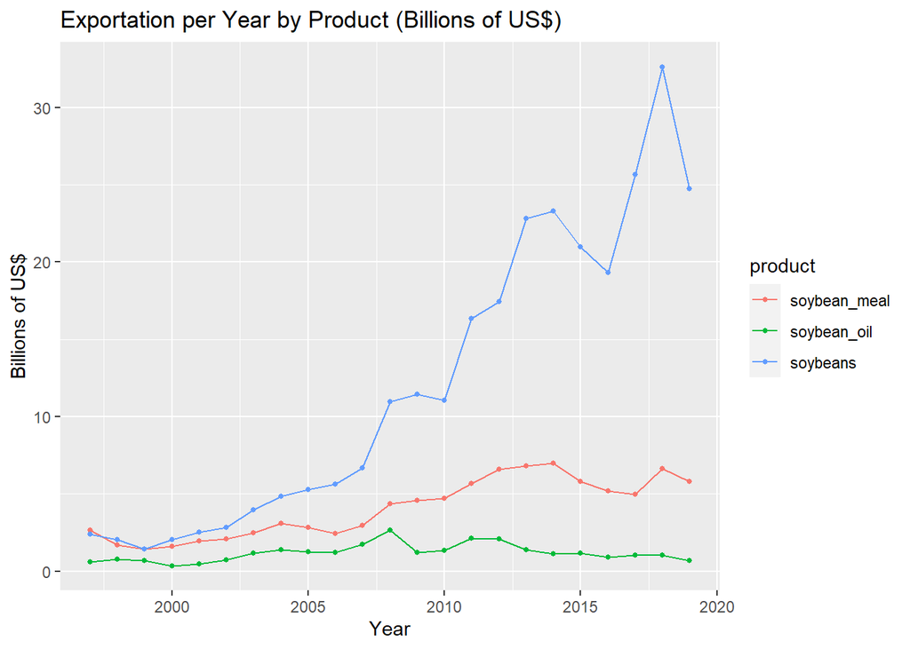

```r
agro_expor_ano %>%
  ggplot(aes(y=usdbil, x=ano, color = product)) + ggtitle("Exportation per Year by Product (Billions of US$) ") + geom_line() + geom_point(size = 1)+ylab("Billions of US$")+xlab("Year")
```

### Total Monthly

- In order to analyze the three products on a monthly basis, it was necessary to separate the charts into 5 periods: between 1997 to 2000, 2001 to 2005, 2006 to 2010, 2011 to 2015 and 2015 to 2019. This separation was necessary for him to be able to clearly observe the differences in product collection per month. In general, in addition to the increasing factor of production analyzed in the previous graph, the seasonality presented by production per month does not vary significantly between 1997 and 2019. Soybeans is the product that most presents this seasonality per month, between November to February, this product has little export compared to the peak months, between April and July. The other two products showed seasonality similar to soybeans, however, marginally, the difference between the peaks and the valleys is not so sharp.

### 97-00

```r
agro_expor_mes_9700 <- agro %>% filter (product %in% c ("soybeans", "soybean_oil", "soybean_meal"), type %in% c ("Export"), date < "2001-01-01") %>%
group_by(date, product) %>%
summarise("tons" = sum(tons), "usdbil" = sum(usdbil)) %>%
  arrange(desc(usdbil))
```

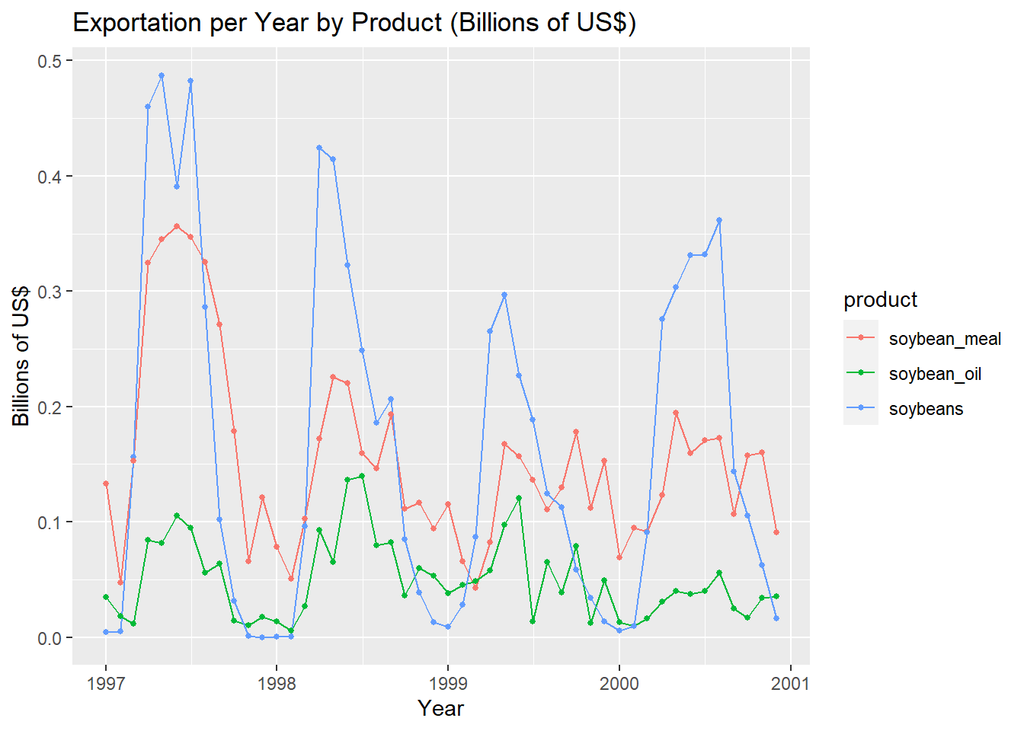

```r
agro_expor_mes_9700 %>% ggplot(aes(y=usdbil, x=date, color = product)) +
  ggtitle("Exportation per Year by Product (Billions of US$)") +
  geom_line() +
  geom_point(size = 1)+
  ylab("Billions of US$")+
  xlab("Year")
```

### 01-05

```r
agro_expor_mes_0105 <- agro %>% filter (product %in% c ("soybeans", "soybean_oil", "soybean_meal"), type %in% c ("Export"), date > "2000-12-01" & date < "2006-01-01") %>%
group_by(date ,product) %>%
summarise("tons" = sum(tons), "usdbil" = sum(usdbil)) %>%
  arrange(desc(usdbil))
```

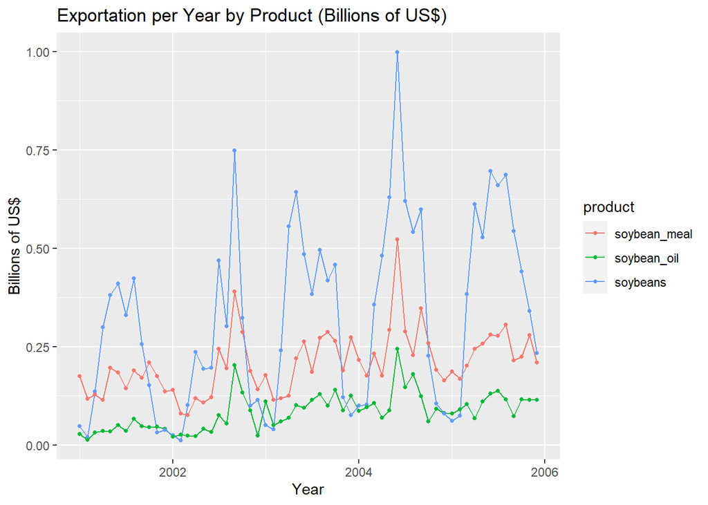

```r
agro_expor_mes_0105 %>% ggplot(aes(y=usdbil, x=date, color = product)) +
  ggtitle("Exportation per Year by Product (Billions of US$)") +
  geom_line() +
  geom_point(size = 1)+
  ylab("Billions of US$")+
  xlab("Year")
```

### 06-10

```r
agro_expor_mes_0105 <- agro %>% filter (product %in% c ("soybeans", "soybean_oil", "soybean_meal"), type %in% c ("Export"), date > "2005-12-01" & date < "2011-01-01") %>%
group_by(date ,product) %>%
summarise("tons" = sum(tons), "usdbil" = sum(usdbil)) %>%
  arrange(desc(usdbil))
```

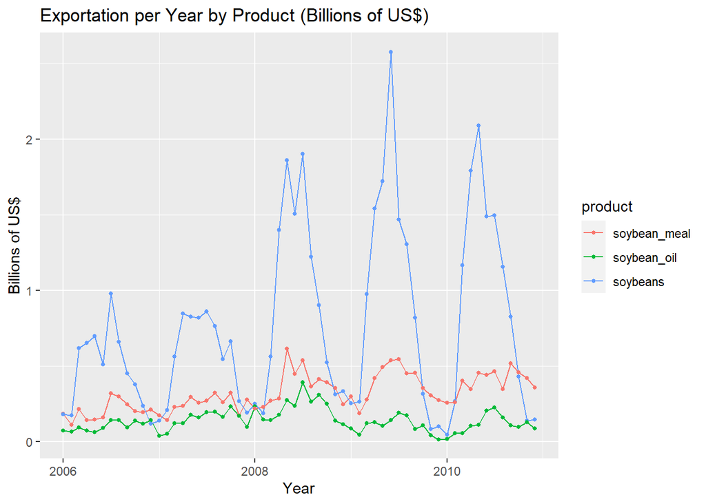

```r
agro_expor_mes_0105 %>% ggplot(aes(y=usdbil, x=date, color = product)) +
  ggtitle("Exportation per Year by Product (Billions of US$)") +
  geom_line() +
  geom_point(size = 1)+
  ylab("Billions of US$")+
  xlab("Year")
```

### 11-15

```r
agro_expor_mes_0105 <- agro %>% filter (product %in% c ("soybeans", "soybean_oil", "soybean_meal"), type %in% c ("Export"), date > "2010-12-31" & date < "2016-01-01") %>%
group_by(date ,product) %>%
summarise("tons" = sum(tons), "usdbil" = sum(usdbil)) %>%
  arrange(desc(usdbil))
```

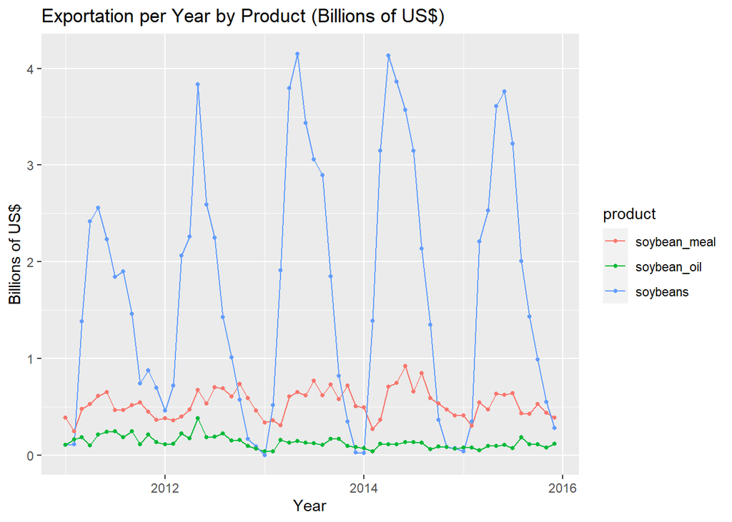

```r
agro_expor_mes_0105 %>% ggplot(aes(y=usdbil, x=date, color = product)) +
  ggtitle("Exportation per Year by Product (Billions of US$)") +
  geom_line() +
  geom_point(size = 1)+
  ylab("Billions of US$")+
  xlab("Year")
```

### 16-20

```r
agro_expor_mes_0105 <- agro %>% filter (product %in% c ("soybeans", "soybean_oil", "soybean_meal"), type %in% c ("Export"), date > "2015-12-01") %>%
group_by(date ,product) %>%
summarise("tons" = sum(tons), "usdbil" = sum(usdbil)) %>%
  arrange(desc(usdbil))
```

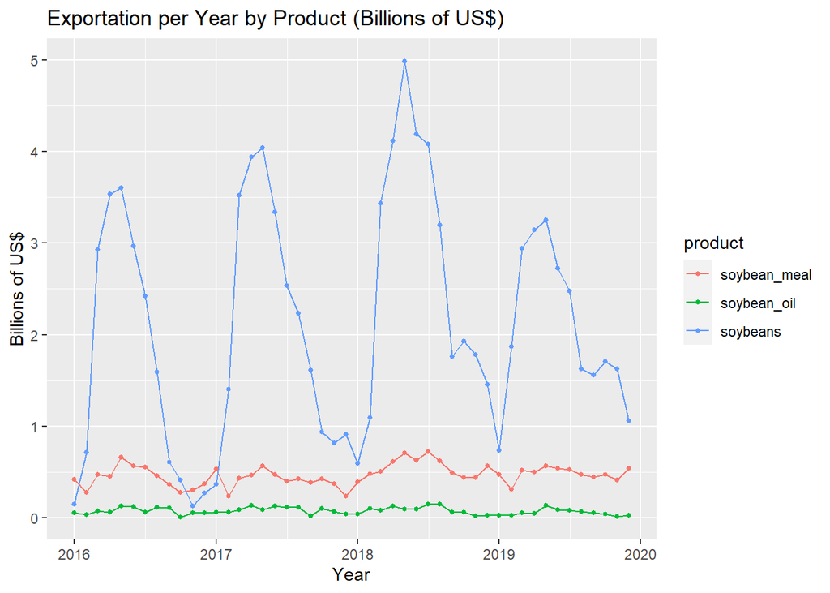

```r
agro_expor_mes_0105 %>% ggplot(aes(y=usdbil, x=date, color = product)) +
  ggtitle("Exportation per Year by Product (Billions of US$)") +
  geom_line() +
  geom_point(size = 1)+
  ylab("Billions of US$")+
  xlab("Year")
```

## 2- What are the 3 most important products exported by Brazil in the last 5 years?

- As we saw earlier, the 3 main products for Brazilian Exportation in the last 5 years were: soybeans, sugar and soybean meal.

```r
agro_top3 <- agro %>%filter ( type %in% c ("Export"), date > "2013-12-01") %>%
  group_by(product) %>%
  summarise("tons" = sum(tons), "usdbil" = sum(usdbil)) %>%
  arrange(desc(usdbil))
agro_top3 %>% head(3)
```

```
## # A tibble: 3 x 3
##   product            tons usdbil
##   <chr>             <dbl>  <dbl>
## 1 soybeans     372018645.  147.
## 2 sugar        143992396.   50.3
## 3 soybean_meal  90363811.   35.4
```

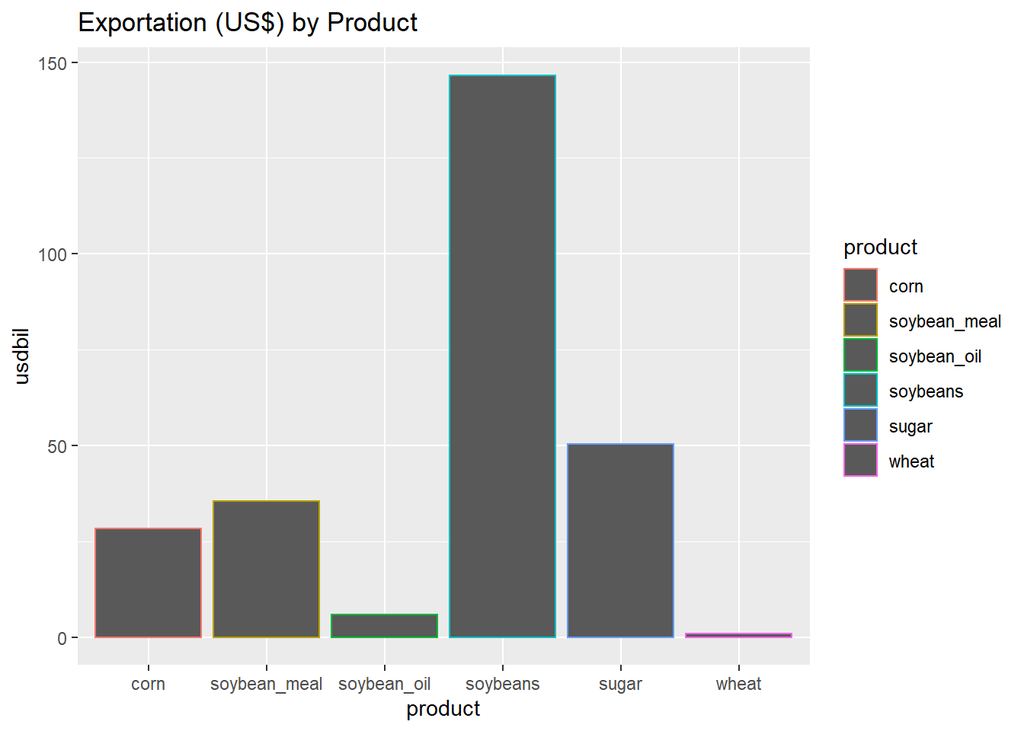

```r
agro_top3 %>% ggplot(aes(x= product, y=usdbil, color = product)) + ggtitle("Exportation (US$) by Product") + geom_col()
```

## 3- What are the main routes through which Brazil have been exporting ‘corn’ in the last few years? Are there differences in the relative importancem of routes depending on the product?

- The main exporting route is through sea, once the main buyers of the brazilian commodity are from other continets and it is the cheapest way to conclude the trade. Although it is a slow transport, sea transport is widely used to transport cargo, since it supports a large quantity and variety of products. This for a relatively low cost, in relation to other means of transport, for example, by air. Due to that, we can not see any differences in the relative importance of routes between the products.

```r
agro_expor_corn <- agro %>% filter (product %in% c ("corn"),type %in% c("Export")) %>%
  group_by( route) %>%
  summarise("tons" = sum(tons), "usdbil" = sum(usdbil)) %>%
  arrange(desc(usdbil)) %>%
  view()
```

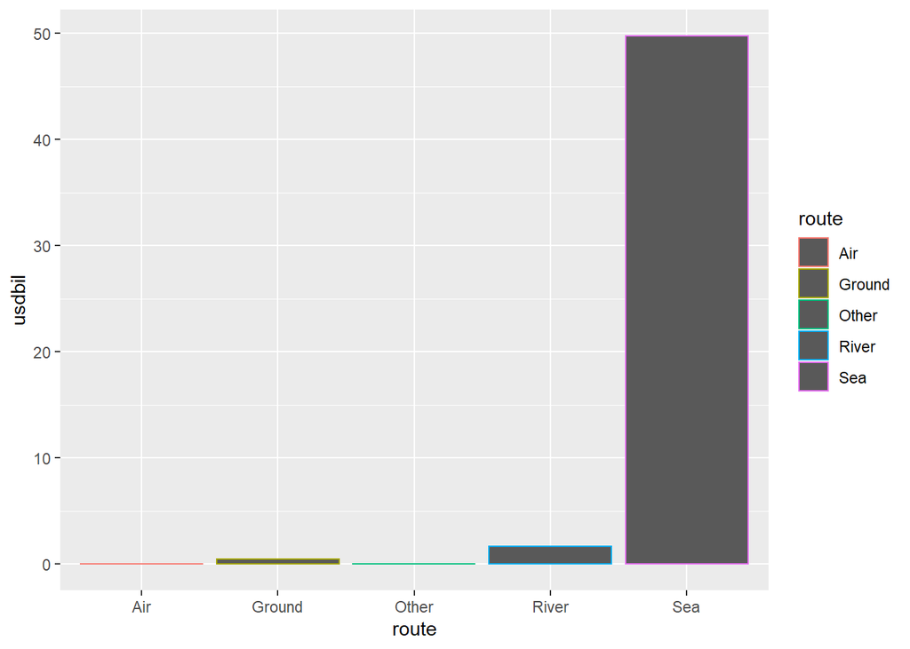

```r
agro_expor_corn %>%
  ggplot(aes( y= usdbil, x = route , color = route)) +
  geom_col()
```

```r
agro_expor_soybeans <- agro %>% filter (product %in% c ("soybeans"),type %in% c("Export")) %>%
  group_by(route) %>%
  summarise("tons" = sum(tons), "usdbil" = sum(usdbil)) %>%
  arrange(desc(usdbil)) %>%
  view()
```

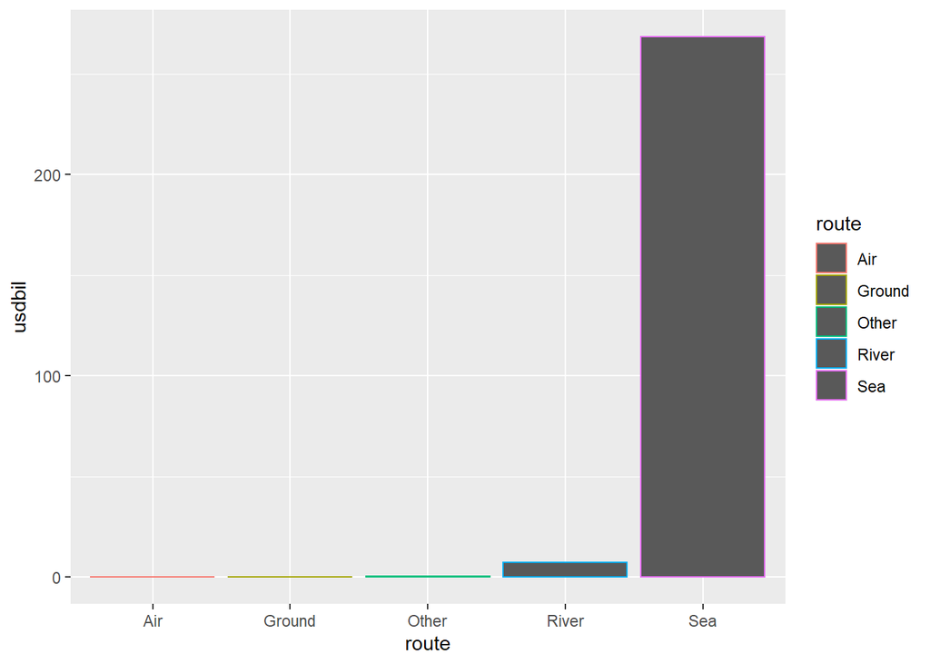

```r
agro_expor_soybeans %>%
  ggplot(aes( y= usdbil, x = route , color = route)) +
  geom_col()
```

```r
agro_expor_soybean_meal <- agro %>% filter (product %in% c ("soybean_meal"),type %in% c("Export")) %>%
  group_by( route) %>%
  summarise("tons" = sum(tons), "usdbil" = sum(usdbil)) %>%
  arrange(desc(usdbil)) %>%
  view()
```

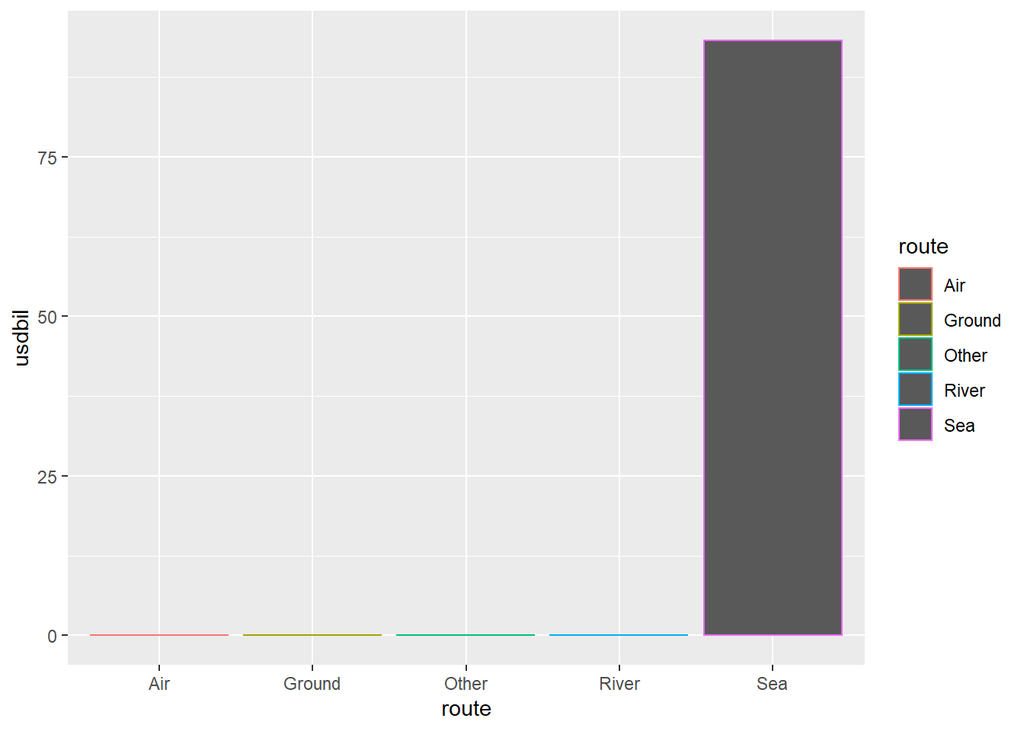

```r
agro_expor_soybean_meal %>%
  ggplot(aes( y= usdbil, x = route , color = route)) +
  geom_col()
```

```r
agro_expor_soybean_oil <- agro %>% filter (product %in% c ("soybean_oil"),type %in% c("Export")) %>%
  group_by( route) %>%
  summarise("tons" = sum(tons), "usdbil" = sum(usdbil)) %>%
  arrange(desc(usdbil)) %>%
  view()
```

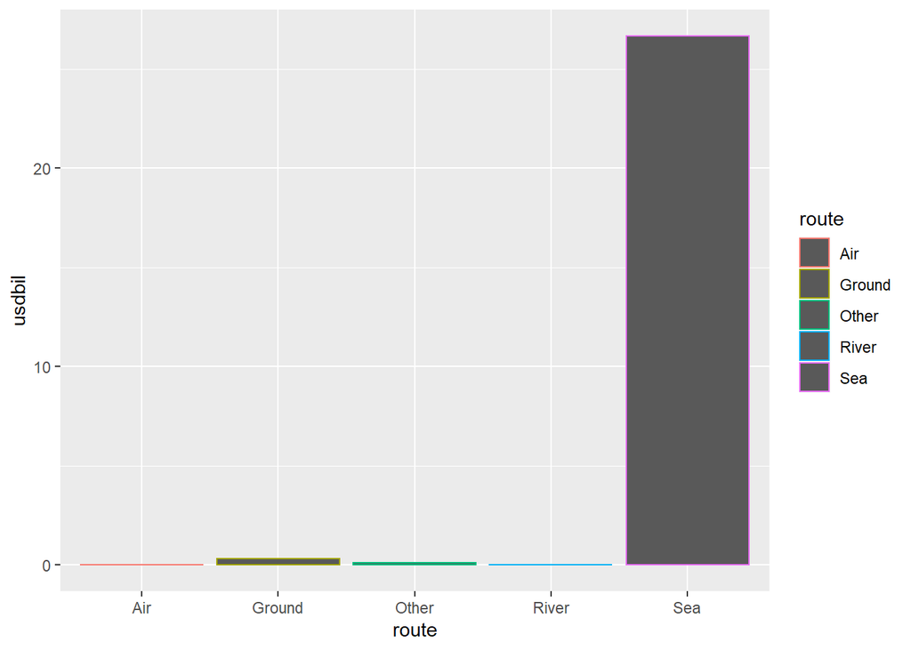

```r
agro_expor_soybean_oil %>%
  ggplot(aes( y= usdbil, x = route , color = route)) +
  geom_col()
```

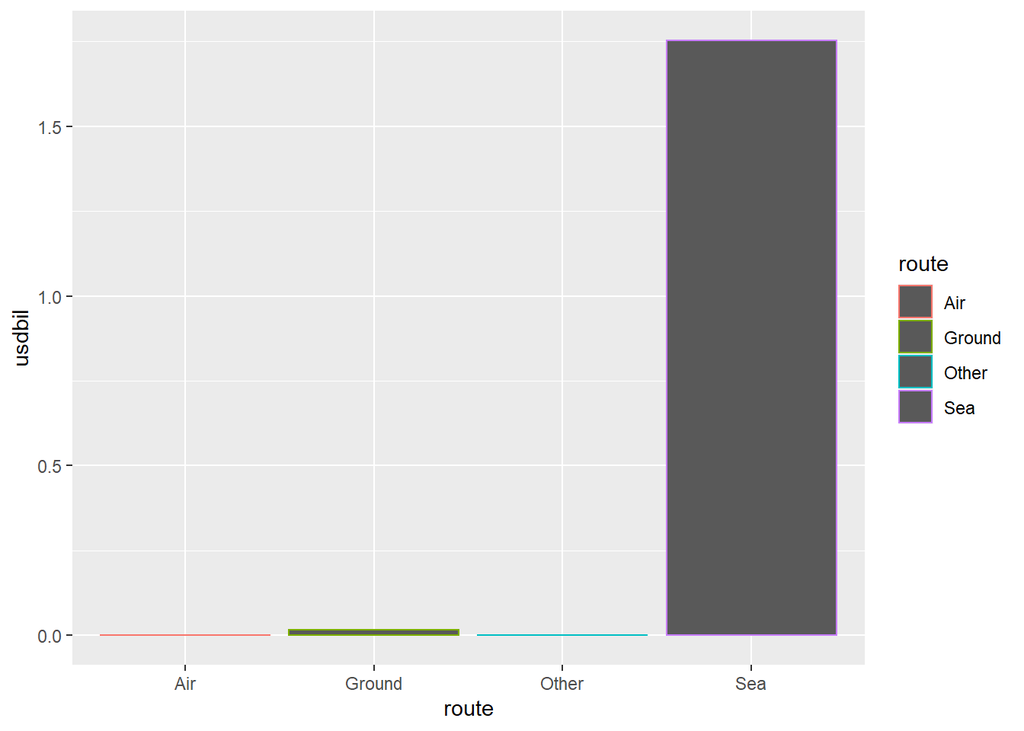

```r
agro_expor_wheat  <- agro %>% filter (product %in% c ("wheat"),type %in% c("Export")) %>%
  group_by( route) %>%
  summarise("tons" = sum(tons), "usdbil" = sum(usdbil)) %>%
  arrange(desc(usdbil)) %>%
  view()
agro_expor_wheat %>%
  ggplot(aes( y= usdbil, x = route , color = route)) +
  geom_col()
```

```r
agro_expor_sugar  <- agro %>% filter (product %in% c ("sugar"),type %in% c("Export")) %>%
  group_by( route) %>%
  summarise("tons" = sum(tons), "usdbil" = sum(usdbil)) %>%
  arrange(desc(usdbil)) %>%
  view()
```

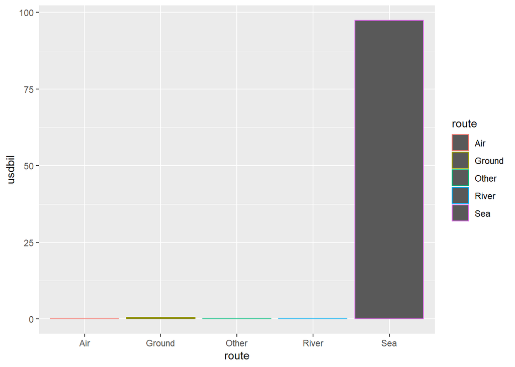

```r
agro_expor_sugar %>%
  ggplot(aes( y= usdbil, x = route , color = route)) +
  geom_col()
```

## 4-Which countries have been the most important trade partners for Brazil in terms of ‘corn’ and ‘sugar’ in the last 3 years?

###Exportation and Importation

```r
agro_top_country_export_import <- agro %>%filter (product %in% c ("corn","sugar"), date > '2016-12-01') %>%
  group_by(country) %>%
  summarise("tons" = sum(tons), "usd" = sum(usd)) %>%
  arrange(desc(usd))
agro_top_country_export_import %>% head(3)
```

```
## # A tibble: 3 x 3
##   country         tons        usd
##   <chr>          <dbl>      <dbl>
## 1 Iran       17857735. 3302427878
## 2 Bangladesh  9560076. 2591053578
## 3 Algeria     8315540. 2441462244
```

###Exportation overall

```r
agro_top_country_export_overall <- agro %>%filter (product %in% c ("corn","sugar"), type %in% c ("Export"), date > '2016-12-01') %>%
  group_by(country) %>%
  summarise("tons" = sum(tons), "usdbil" = sum(usdbil)) %>%
  arrange(desc(usdbil))
agro_top_country_export_overall %>% head(3)
```

```
## # A tibble: 3 x 3
##   country         tons usdbil
##   <chr>          <dbl>  <dbl>
## 1 Iran       17857735.   3.30
## 2 Bangladesh  9560076.   2.59
## 3 Algeria     8315540.   2.44
```

###Exportation by product

```r
agro_top_country_export_product <- agro %>%filter (product %in% c ("corn","sugar"), type %in% c ("Export"), date > '2016-12-01') %>%
  group_by(country, product) %>%
  summarise("tons" = sum(tons), "usd" = sum(usd))%>%
  arrange(desc(usd))
agro_top_country_export_product %>% head(10)
```

```
## # A tibble: 10 x 4
## # Groups:   country [10]
##    country              product      tons        usd
##    <chr>                <chr>       <dbl>      <dbl>
##  1 Iran                 corn    16425650. 2822336281
##  2 Algeria              sugar    6696854. 2176380928
##  3 Bangladesh           sugar    6331640. 2063174600
##  4 India                sugar    5111372. 1696094938
##  5 Japan                corn     9676921. 1574975592
##  6 Vietnam              corn     9446982. 1551035208
##  7 United Arab Emirates sugar    4545802. 1538397895
##  8 Saudi Arabia         sugar    4249462. 1380455693
##  9 Egypt                corn     8353797. 1375065136
## 10 Nigeria              sugar    4156814. 1336515029
```

###Importation overall

```r
agro_top_country_import_overall <- agro %>%filter (product %in% c ("corn",'sugar'), type %in% c ("Import"), date > '2016-12-01') %>%
  group_by(country) %>%
  summarise("tons" = sum(tons), "usd" = sum(usd))%>%
  arrange(desc(usd))
agro_top_country_import_overall %>% head(3)
```

```
## # A tibble: 3 x 3
##   country           tons       usd
##   <chr>            <dbl>     <dbl>
## 1 Paraguay      2842390. 374247027
## 2 Argentina      819866. 155419774
## 3 United States    6488.  24141814
```

```r
agro_top_country_import_product <- agro %>%filter (product %in% c ("corn",'sugar'), date > '2017-01-1') %>%
  group_by(country, product) %>%
  summarise("tons" = sum(tons), "usd" = sum(usd))%>%
  arrange(desc(usd))
agro_top_country_import_product %>% head(10)
```

```
## # A tibble: 10 x 4
## # Groups:   country [10]
##    country              product      tons        usd
##    <chr>                <chr>       <dbl>      <dbl>
##  1 Iran                 corn    15748857. 2704816938
##  2 Algeria              sugar    6503826. 2095527679
##  3 Bangladesh           sugar    6068078. 1959037692
##  4 India                sugar    4993783. 1644253262
##  5 Japan                corn     9676921. 1574975592
##  6 Vietnam              corn     9236604. 1518541174
##  7 United Arab Emirates sugar    4414862. 1481254457
##  8 Egypt                corn     8353597. 1374531252
##  9 Spain                corn     8243946. 1335780242
## 10 Saudi Arabia         sugar    4122215. 1321692164
```

## 5 - For each of the products in the dataset, show the 5 most important states in terms of exports

- As we could see and explain in the previous question, the results change from the perspective we observe. We can analyze the by the total amount (US$) exported, which we can rank the top 5 states, which is Mato Grosso, Paraná, São Paulo, Rio Grande do Sul and Goiás. If we split the data through each product, we can find another sequence of top states: corn (MT, PR, GO, MS, SP), soybean_meal(MT, PR, RS, GO, BA), soybean_oil (PR, RS, MT, SC, GO), soybeans(MT, PR, RS, GO, MS), sugar (SP, MG, PR, AL, MS) and wheat (RS, PR, SC, SP, MS).

###Exportation overall by state

```r
agro_state <- agro %>%filter (type %in% c ("Export")) %>%
  group_by(state) %>%
  summarise("tons" = sum(tons), "usd" = sum(usd)) %>%
  arrange(desc(usd))
agro_state %>%
  head(5)
```

```
## # A tibble: 5 x 3
##   state       tons          usd
##   <chr>      <dbl>        <dbl>
## 1 MT    455165464. 142540469999
## 2 PR    314098937. 101858391966
## 3 SP    246810138.  85324704983
## 4 RS    190746050.  70219677967
## 5 GO    122397633.  40294067858
```

###Exportation overall by state and corn

```r
agro_state_corn <- agro %>%filter (type %in% c ("Export"), product %in% c ("corn")) %>%
  group_by(state) %>%
  summarise("tons" = sum(tons), "usd" = sum(usd)) %>%
  arrange(desc(usd))
agro_state_corn %>%
  head(5)
```

```
## # A tibble: 5 x 3
##   state       tons         usd
##   <chr>      <dbl>       <dbl>
## 1 MT    151823362. 28375516035
## 2 PR     53862466.  9160511995
## 3 GO     28464620.  5706990655
## 4 MS     18270595.  3405430680
## 5 SP      7343888.  1511121926
```

###Exportation overall by state and soybean_meal

```r
agro_state_soybean_meal<- agro %>%filter (type %in% c ("Export"), product %in% c ("soybean_meal")) %>%
  group_by(state) %>%
  summarise("tons" = sum(tons), "usd" = sum(usd)) %>%
  arrange(desc(usd))
agro_state_soybean_meal %>%
  head(5)
```

```
## # A tibble: 5 x 3
##   state      tons         usd
##   <chr>     <dbl>       <dbl>
## 1 MT    79462275. 27994539842
## 2 PR    86392369. 24649962821
## 3 RS    48927459. 15007385729
## 4 GO    28686580.  9421430703
## 5 BA    17368056.  5439265638
```

###Exportation overall by state and soybean_oil

```r
agro_state_soybean_oil<- agro %>%filter (type %in% c ("Export"), product %in% c ("soybean_oil")) %>%
  group_by(state) %>%
  summarise("tons" = sum(tons), "usd" = sum(usd)) %>%
  arrange(desc(usd))
agro_state_soybean_oil %>%
  head(5)
```

```
## # A tibble: 5 x 3
##   state      tons         usd
##   <chr>     <dbl>       <dbl>
## 1 PR    16482050. 11109102057
## 2 RS     9279786.  6281965055
## 3 MT     7423877.  5434513926
## 4 SC     1786134.  1238810673
## 5 GO     1094295.   855920734
```

###Exportation overall by state and soybeans

```r
agro_state_soybeans <- agro %>%filter (type %in% c ("Export"), product %in% c ("soybeans")) %>%
  group_by(state) %>%
  summarise("tons" = sum(tons), "usd" = sum(usd)) %>%
  arrange(desc(usd))
agro_state_soybeans %>%
  head(5)
```

```
## # A tibble: 5 x 3
##   state       tons         usd
##   <chr>      <dbl>       <dbl>
## 1 MT    215778483. 80506781707
## 2 PR    134550202. 48484101052
## 3 RS    119680726. 46136733396
## 4 GO     57025330. 21268827303
## 5 MS     34214636. 13284815678
```

###Exportation overall by state and sugar

```r
agro_state_sugar <- agro %>%filter (type %in% c ("Export"), product %in% c ("sugar")) %>%
  group_by(state) %>%
  summarise("tons" = sum(tons), "usd" = sum(usd)) %>%
  arrange(desc(usd))
agro_state_sugar %>%
  head(5)
```

```
## # A tibble: 5 x 3
##   state       tons         usd
##   <chr>      <dbl>       <dbl>
## 1 SP    187960318. 66211861392
## 2 MG     23182925.  8559401218
## 3 PR     21986875.  8270778644
## 4 AL     12617940.  4826419200
## 5 MS      8406289.  3219034929
```

###Exportation overall by state and wheat

```r
agro_state_wheat <- agro %>%filter (type %in% c ("Export"), product %in% c ("wheat")) %>%
  group_by(state) %>%
  summarise("tons" = sum(tons), "usd" = sum(usd)) %>%
  arrange(desc(usd))
agro_state_wheat %>%
  head(5)
```

```
## # A tibble: 5 x 3
##   state     tons        usd
##   <chr>    <dbl>      <dbl>
## 1 RS    6734981. 1555925283
## 2 PR     824975.  183935397
## 3 SC      81341.   25400089
## 4 SP      10067.    2267024
## 5 MS        910.     275733
```

## 6- What should be the total brazilian soybeans, soybean_meal, and corn export forecasts, in tons, for the next 11 years (2020-2030)? We’re mostly interested in the annual forecast.

- In order to answer this question and project these products, we believe that the best model to use is the Vector autoregression (VAR). However, it is a poor predictive model, and it is prudent to analyze it by the sign of its Granger coefficient. VAR is a statistical model used to capture the relationship between multiple quantities as they change over time. VAR is a type of stochastic process model. VAR models generalize the single-variable (univariate) autoregressive model by allowing for multivariate time series
- Keep only the soybeans, soybean_meal, and corn for exportation

```r
agro2 <- agro[agro$type=="Export",]
View(agro2)
agro3 <- agro2[agro2$product %in% c ("soybeans","soybean_meal", "corn"),]
View(agro3)
```

- Aggregate the database by year and product

```r
if(!require(plyr)){install.packages("plyr", dependencies = TRUE); library(plyr)}
agro4 <- ddply(agro3, .(product, ano), summarize, tons=sum(tons), usd=sum(usd), usdbil=sum(usdbil))
view(agro4)
agro4 <- rename (agro4, c(ano="year"))

covariates <- read_excel("covariates.xlsx")
View(covariates)

agro5 <- merge(agro4, covariates, by="year")
view(agro5)
```

- Separate the databases by product

```r
agrosb <- agro5[agro5$product=="soybeans",]
agroco <- agro5[agro5$product=="corn",]
agrosm <- agro5[agro5$product=="soybean_meal",]
```

- Declare our time series variable

```r
tonstssb <- ts(agrosb$tons, start = c(1997), frequency = 1)
price_soybeansts <- ts(agrosb$price_soybeans, start = c(1997), frequency = 1)

tonstsco <- ts(agroco$tons, start = c(1997), frequency = 1)
price_cornts <- ts(agroco$price_corn, start = c(1997), frequency = 1)

tonstssm <- ts(agrosm$tons, start = c(1997), frequency = 1)
price_soybean_mealts <- ts(agrosm$price_soybean_meal, start = c(1997), frequency = 1)
```

- Taking the hiatus out of the gdp
- We made a more cautious model and took the hiatus and used only the global GDP in our model.

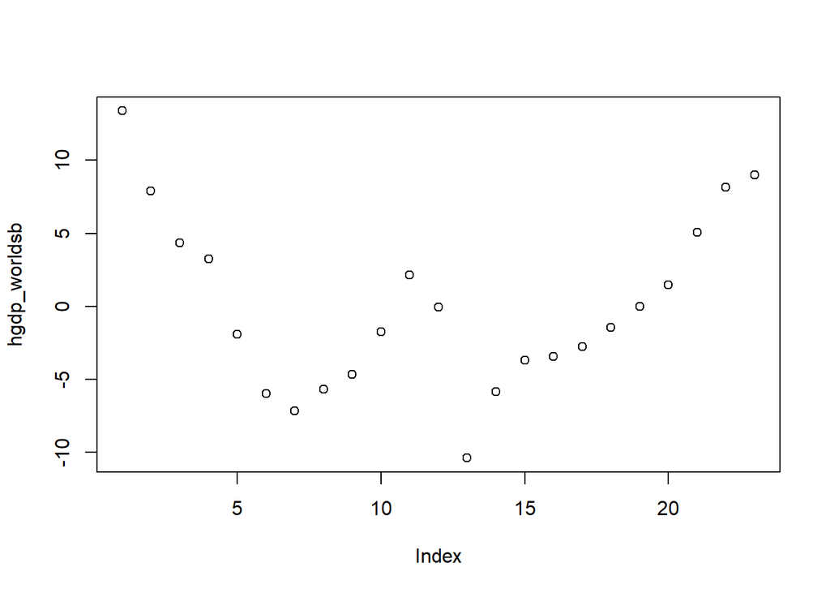

```r
fgdp_worldsb <- hpfilter(agrosb$gdp_world, freq = 14400)
hgdp_worldsb <- fgdp_worldsb$cycle
plot(hgdp_worldsb)
```

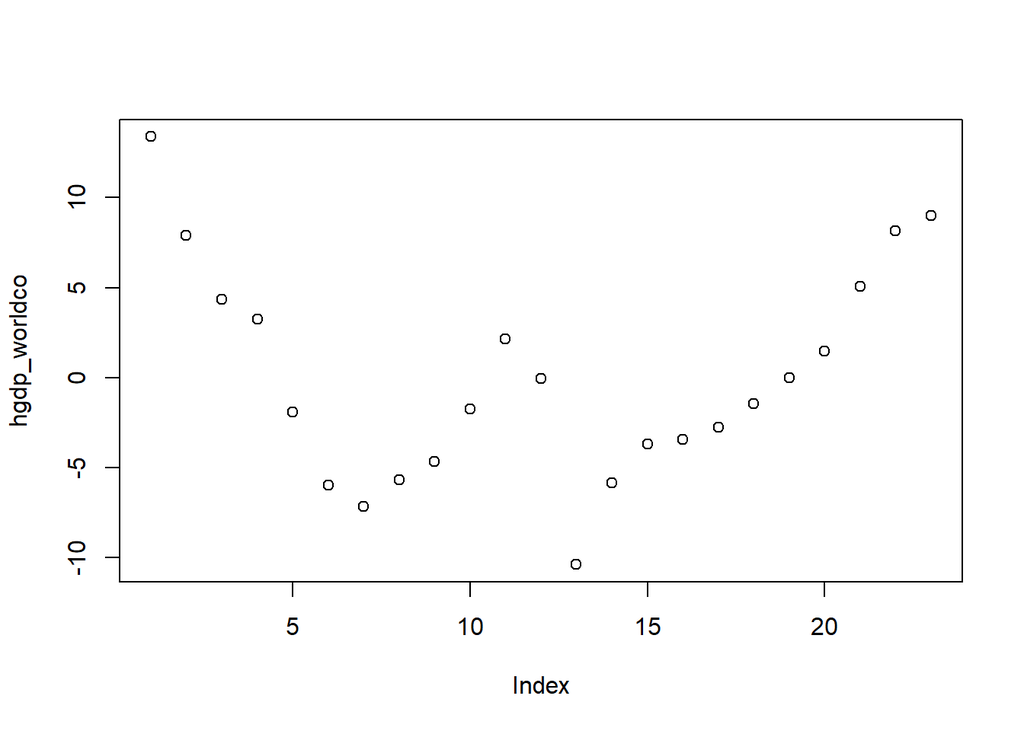

```r
fgdp_worldco <- hpfilter(agroco$gdp_world, freq = 14400)
hgdp_worldco <- fgdp_worldco$cycle
plot(hgdp_worldco)
```

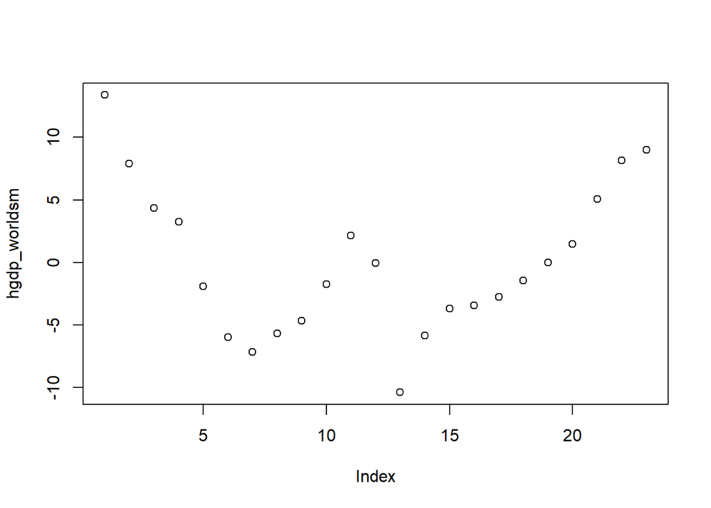

```r
fgdp_worldsm <- hpfilter(agrosm$gdp_world, freq = 14400)
hgdp_worldsm <- fgdp_worldsm$cycle
plot(hgdp_worldsm)
```

- Determine the Persistence of the Model
- Despite having multicollinearity in the 3 products, they were not as persistent as observed in the previous exercise.

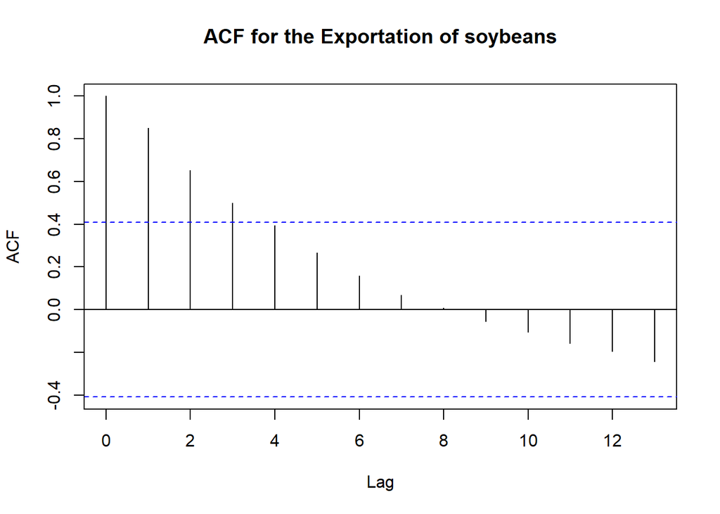

```r
acf(tonstssb, main = "ACF for the Exportation of soybeans", data= agrosb)
```

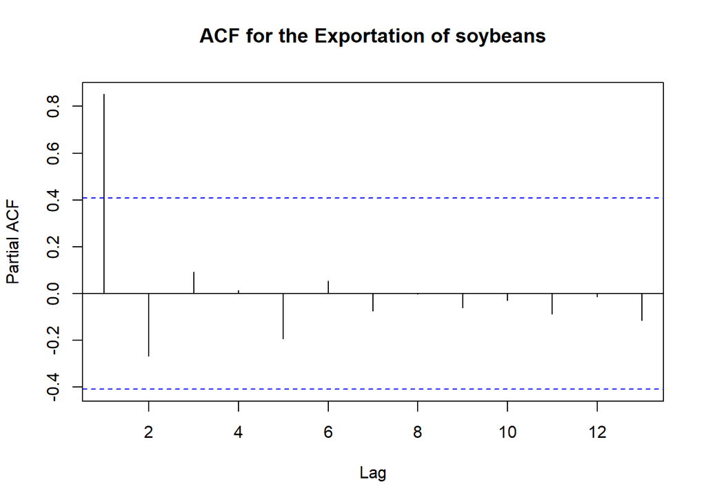

```r
pacf(tonstssb, main = "ACF for the Exportation of soybeans", data= agrosb)
```

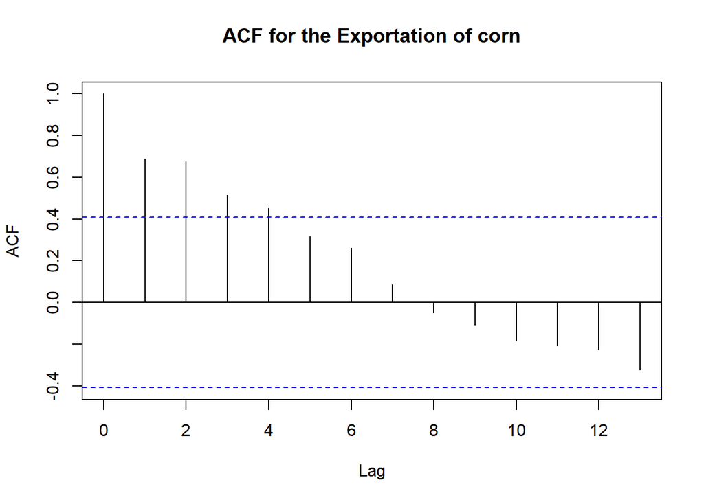

```r
acf(tonstsco, main = "ACF for the Exportation of corn", data= agroco)
```

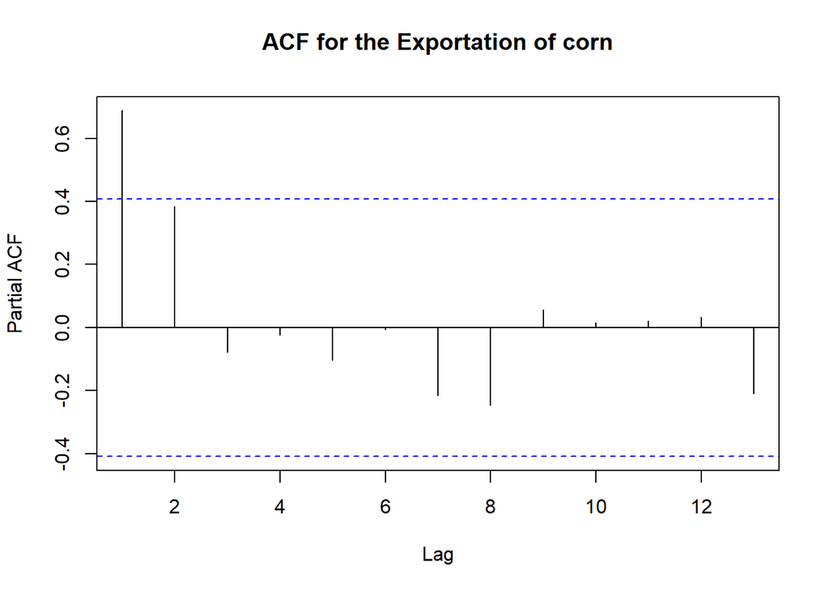

```r
pacf(tonstsco, main = "ACF for the Exportation of corn", data= agroco)
```

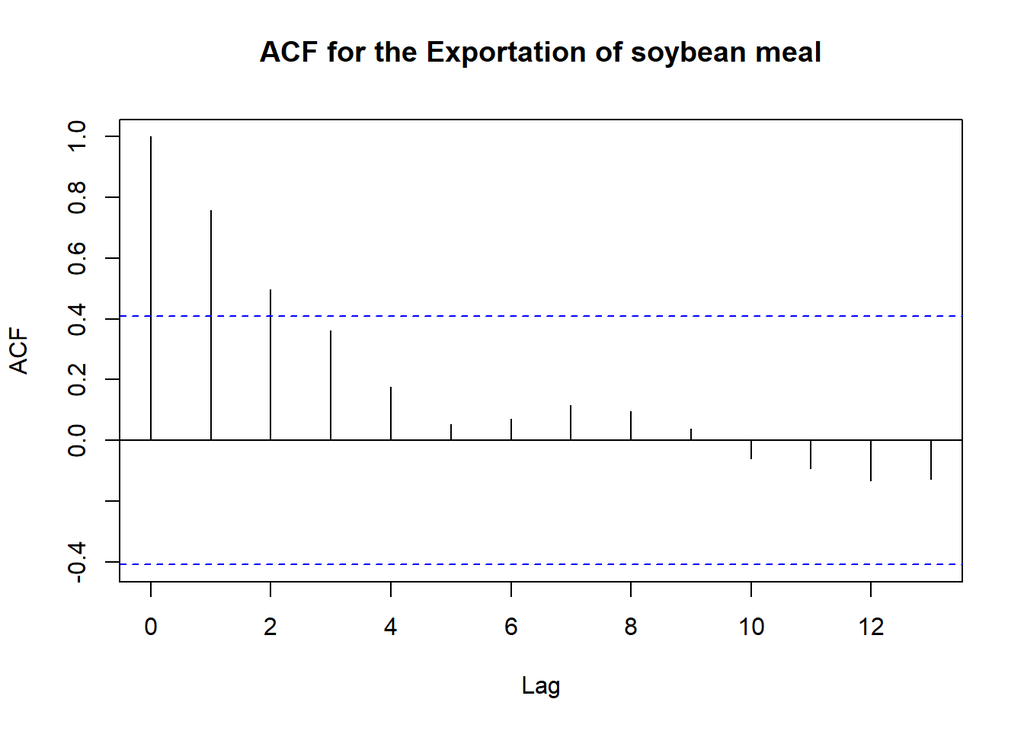

```r
acf(tonstssm, main = "ACF for the Exportation of soybean meal", data= agrosm)
```

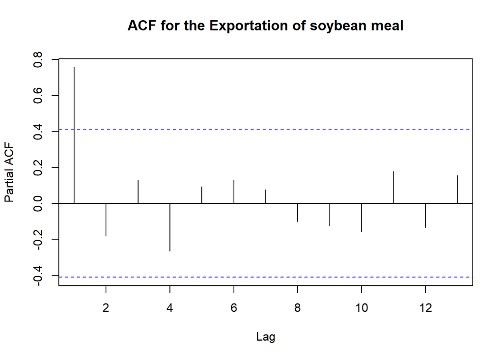

```r
pacf(tonstssm, main = "ACF for the Exportation of soybean meal", data= agrosm)
```

* Finding the optimal lags

```r
tonssb.bv <- cbind(tonstssb, price_soybeansts, hgdp_worldsb)
colnames(tonssb.bv) <- cbind("Ton","Price", "GDP World")

tonsco.bv <- cbind(tonstsco, price_cornts, hgdp_worldco)
colnames(tonsco.bv) <- cbind("Ton","Price", "GDP World")

tonssm.bv <- cbind(tonstssm, price_soybean_mealts, hgdp_worldsm)
colnames(tonssm.bv) <- cbind("Ton","Price", "GDP World")
```

- LAG selection

```r
lagselect1 <- VARselect(tonssb.bv, lag.max=10, type="const")
lagselect1$selection
```

```
## AIC(n)  HQ(n)  SC(n) FPE(n)
##      4      4      4      5
```

```r
lagselect2 <- VARselect(tonsco.bv, lag.max=10, type="const")
lagselect2$selection
```

```
## AIC(n)  HQ(n)  SC(n) FPE(n)
##      4      4      4      5
```

```r
lagselect3 <- VARselect(tonssm.bv, lag.max=10, type="const")
lagselect3$selection
```

```
## AIC(n)  HQ(n)  SC(n) FPE(n)
##      4      4      4      5
```

## Building VAR

```r
ModelSoyBeans <- VAR(tonssb.bv, p=4, type="const", season=NULL, exog= NULL)
summary(ModelSoyBeans)
```

```
##
## VAR Estimation Results:
## =========================
## Endogenous variables: Ton, Price, GDP.World
## Deterministic variables: const
## Sample size: 19
## Log Likelihood: -409.027
## Roots of the characteristic polynomial:
## 1.325 1.325 1.075 1.075 0.9503 0.9503 0.8339 0.8339 0.8143 0.8143 0.5444 0.5444
## Call:
## VAR(y = tonssb.bv, p = 4, type = "const", exogen = NULL)
##
##
## Estimation results for equation Ton:
## ====================================
## Ton = Ton.l1 + Price.l1 + GDP.World.l1 + Ton.l2 + Price.l2 + GDP.World.l2 + Ton.l3 + Price.l3 + GDP.World.l3 + Ton.l4 + Price.l4 + GDP.World.l4 + const
##
##                Estimate Std. Error t value Pr(>|t|)
## Ton.l1        8.423e-02  6.529e-01   0.129    0.902
## Price.l1     -8.737e+04  1.119e+05  -0.781    0.465
## GDP.World.l1  4.695e+05  8.731e+05   0.538    0.610
## Ton.l2       -1.876e-01  7.804e-01  -0.240    0.818
## Price.l2      1.455e+05  2.190e+05   0.665    0.531
## GDP.World.l2 -1.625e+06  1.055e+06  -1.540    0.174
## Ton.l3        1.782e-01  7.745e-01   0.230    0.826
## Price.l3     -2.646e+05  1.982e+05  -1.335    0.230
## GDP.World.l3  1.512e+06  9.541e+05   1.585    0.164
## Ton.l4        1.228e+00  8.687e-01   1.413    0.207
## Price.l4      2.522e+05  1.459e+05   1.729    0.135
## GDP.World.l4 -6.655e+05  7.004e+05  -0.950    0.379
## const        -5.364e+05  5.711e+06  -0.094    0.928
##
##
## Residual standard error: 5595000 on 6 degrees of freedom
## Multiple R-Squared: 0.9744,  Adjusted R-squared: 0.9232
## F-statistic: 19.03 on 12 and 6 DF,  p-value: 0.0008528
##
##
## Estimation results for equation Price:
## ======================================
```

[output cut: 49 more lines]

```
## F-statistic: 8.351 on 12 and 6 DF,  p-value: 0.008141
##
##
##
## Covariance matrix of residuals:
##                  Ton      Price  GDP.World
## Ton        3.131e+13 -1.250e+08 -1.142e+06
## Price     -1.250e+08  8.235e+02  2.401e+01
## GDP.World -1.142e+06  2.401e+01  4.342e+00
##
## Correlation matrix of residuals:
##                Ton   Price GDP.World
## Ton        1.00000 -0.7784  -0.09795
## Price     -0.77840  1.0000   0.40157
## GDP.World -0.09795  0.4016   1.00000
```

```r
ModelCorn <- VAR(tonsco.bv, p=4, type="const", season=NULL, exog= NULL)
summary(ModelCorn)
```

```
##
## VAR Estimation Results:
## =========================
## Endogenous variables: Ton, Price, GDP.World
## Deterministic variables: const
## Sample size: 19
## Log Likelihood: -421.41
## Roots of the characteristic polynomial:
## 1.049 1.009 1.009 0.8637 0.8637 0.8436 0.8436 0.7966 0.7966 0.6023 0.4484 0.4484
## Call:
## VAR(y = tonsco.bv, p = 4, type = "const", exogen = NULL)
##
##
## Estimation results for equation Ton:
## ====================================
## Ton = Ton.l1 + Price.l1 + GDP.World.l1 + Ton.l2 + Price.l2 + GDP.World.l2 + Ton.l3 + Price.l3 + GDP.World.l3 + Ton.l4 + Price.l4 + GDP.World.l4 + const
##
##                Estimate Std. Error t value Pr(>|t|)
## Ton.l1       -5.376e-01  4.641e-01  -1.158    0.291
## Price.l1     -3.703e+03  7.077e+04  -0.052    0.960
## GDP.World.l1  8.880e+05  7.092e+05   1.252    0.257
## Ton.l2        3.286e-01  4.241e-01   0.775    0.468
## Price.l2      1.787e+05  1.185e+05   1.508    0.182
## GDP.World.l2 -2.937e+05  9.627e+05  -0.305    0.771
## Ton.l3        2.860e-01  4.480e-01   0.638    0.547
## Price.l3     -8.189e+04  1.146e+05  -0.715    0.502
## GDP.World.l3 -8.232e+04  9.448e+05  -0.087    0.933
## Ton.l4        5.752e-01  4.595e-01   1.252    0.257
## Price.l4      2.948e+04  8.020e+04   0.368    0.726
## GDP.World.l4  2.236e+05  5.788e+05   0.386    0.713
## const        -4.713e+06  5.058e+06  -0.932    0.387
##
##
## Residual standard error: 5696000 on 6 degrees of freedom
## Multiple R-Squared: 0.9187,  Adjusted R-squared: 0.7562
## F-statistic: 5.652 on 12 and 6 DF,  p-value: 0.02201
##
##
## Estimation results for equation Price:
## ======================================
```

[output cut: 49 more lines]

```
## F-statistic: 4.814 on 12 and 6 DF,  p-value: 0.03248
##
##
##
## Covariance matrix of residuals:
##                 Ton     Price GDP.World
## Ton       3.244e+13 2.584e+07 7.883e+06
## Price     2.584e+07 9.645e+02 4.374e+01
## GDP.World 7.883e+06 4.374e+01 7.233e+00
##
## Correlation matrix of residuals:
##              Ton  Price GDP.World
## Ton       1.0000 0.1461    0.5146
## Price     0.1461 1.0000    0.5237
## GDP.World 0.5146 0.5237    1.0000
```

```r
ModelSoyBeanMeal <- VAR(tonssm.bv, p=4, type="const", season=NULL, exog= NULL)
summary(ModelSoyBeanMeal)
```

```
##
## VAR Estimation Results:
## =========================
## Endogenous variables: Ton, Price, GDP.World
## Deterministic variables: const
## Sample size: 19
## Log Likelihood: -375.598
## Roots of the characteristic polynomial:
##  1.19 1.002 0.9329 0.9329 0.8895 0.8895 0.8611 0.8611 0.7092 0.6987 0.6987 0.6969
## Call:
## VAR(y = tonssm.bv, p = 4, type = "const", exogen = NULL)
##
##
## Estimation results for equation Ton:
## ====================================
## Ton = Ton.l1 + Price.l1 + GDP.World.l1 + Ton.l2 + Price.l2 + GDP.World.l2 + Ton.l3 + Price.l3 + GDP.World.l3 + Ton.l4 + Price.l4 + GDP.World.l4 + const
##
##                Estimate Std. Error t value Pr(>|t|)
## Ton.l1        8.344e-01  2.873e-01   2.904   0.0272 *
## Price.l1      7.297e+03  1.430e+04   0.510   0.6281
## GDP.World.l1 -1.606e+05  1.818e+05  -0.883   0.4111
## Ton.l2        9.058e-02  4.919e-01   0.184   0.8599
## Price.l2     -7.792e+03  2.438e+04  -0.320   0.7600
## GDP.World.l2 -3.050e+04  1.424e+05  -0.214   0.8375
## Ton.l3        4.601e-01  4.962e-01   0.927   0.3896
## Price.l3     -1.044e+04  2.525e+04  -0.414   0.6935
## GDP.World.l3  1.135e+05  1.322e+05   0.858   0.4238
## Ton.l4        1.737e-01  4.693e-01   0.370   0.7241
## Price.l4      1.219e+04  2.050e+04   0.595   0.5738
## GDP.World.l4  1.729e+05  1.350e+05   1.281   0.2474
## const        -6.667e+06  7.748e+06  -0.860   0.4226
## ---
## Signif. codes:  0 '***' 0.001 '**' 0.01 '*' 0.05 '.' 0.1 ' ' 1
##
##
## Residual standard error: 1088000 on 6 degrees of freedom
## Multiple R-Squared: 0.8274,  Adjusted R-squared: 0.4823
## F-statistic: 2.397 on 12 and 6 DF,  p-value: 0.1461
##
##
```

[output cut: 51 more lines]

```
## F-statistic: 19.87 on 12 and 6 DF,  p-value: 0.0007553
##
##
##
## Covariance matrix of residuals:
##                  Ton      Price GDP.World
## Ton        1.183e+12 -3.975e+06 5.508e+05
## Price     -3.975e+06  6.825e+02 1.529e+01
## GDP.World  5.508e+05  1.529e+01 1.887e+00
##
## Correlation matrix of residuals:
##               Ton   Price GDP.World
## Ton        1.0000 -0.1399    0.3686
## Price     -0.1399  1.0000    0.4260
## GDP.World  0.3686  0.4260    1.0000
```

### Diagnosing the VAR

- Serial Correlation

```r
Serial1 <- serial.test(ModelSoyBeans, lags.pt=12, type= "PT.asymptotic")
Serial1
```

```
##
##  Portmanteau Test (asymptotic)
##
## data:  Residuals of VAR object ModelSoyBeans
## Chi-squared = 83.096, df = 72, p-value = 0.1746
```

```r
Serial2 <- serial.test(ModelCorn, lags.pt=12, type= "PT.asymptotic")
Serial2
```

```
##
##  Portmanteau Test (asymptotic)
##
## data:  Residuals of VAR object ModelCorn
## Chi-squared = 81.712, df = 72, p-value = 0.2031
```

```r
Serial3 <- serial.test(ModelSoyBeanMeal, lags.pt=12, type= "PT.asymptotic")
Serial3
```

```
##
##  Portmanteau Test (asymptotic)
##
## data:  Residuals of VAR object ModelSoyBeanMeal
## Chi-squared = 79.942, df = 72, p-value = 0.2438
```

- Heteroscedasticity

```r
Arch1 <- arch.test(ModelSoyBeans, lags.multi=12, multivariate.only=TRUE)
Arch1
```

```
##
##  ARCH (multivariate)
##
## data:  Residuals of VAR object ModelSoyBeans
## Chi-squared = 42, df = 432, p-value = 1
```

```r
Arch2 <- arch.test(ModelCorn, lags.multi=12, multivariate.only=TRUE)
Arch2
```

```
##
##  ARCH (multivariate)
##
## data:  Residuals of VAR object ModelCorn
## Chi-squared = 42, df = 432, p-value = 1
```

```r
Arch3 <- arch.test(ModelSoyBeanMeal, lags.multi=12, multivariate.only=TRUE)
Arch3
```

```
##
##  ARCH (multivariate)
##
## data:  Residuals of VAR object ModelSoyBeanMeal
## Chi-squared = 42, df = 432, p-value = 1
```

- Normal Distribution of the Residuals

```r
Normal1 <- normality.test(ModelSoyBeans, multivariate.only=TRUE)
Normal1
```

```
## $JB
##
##  JB-Test (multivariate)
##
## data:  Residuals of VAR object ModelSoyBeans
## Chi-squared = 1.6283, df = 6, p-value = 0.9505
##
##
## $Skewness
##
##  Skewness only (multivariate)
##
## data:  Residuals of VAR object ModelSoyBeans
## Chi-squared = 0.50117, df = 3, p-value = 0.9186
##
##
## $Kurtosis
##
##  Kurtosis only (multivariate)
##
## data:  Residuals of VAR object ModelSoyBeans
## Chi-squared = 1.1272, df = 3, p-value = 0.7705
```

```r
Normal2 <- normality.test(ModelCorn, multivariate.only=TRUE)
Normal2
```

```
## $JB
##
##  JB-Test (multivariate)
##
## data:  Residuals of VAR object ModelCorn
## Chi-squared = 4.192, df = 6, p-value = 0.6507
##
##
## $Skewness
##
##  Skewness only (multivariate)
##
## data:  Residuals of VAR object ModelCorn
## Chi-squared = 1.7145, df = 3, p-value = 0.6337
##
##
## $Kurtosis
##
##  Kurtosis only (multivariate)
##
## data:  Residuals of VAR object ModelCorn
## Chi-squared = 2.4775, df = 3, p-value = 0.4794
```

```r
Normal3 <- normality.test(ModelSoyBeanMeal, multivariate.only=TRUE)
Normal3
```

```
## $JB
##
##  JB-Test (multivariate)
##
## data:  Residuals of VAR object ModelSoyBeanMeal
## Chi-squared = 3.5958, df = 6, p-value = 0.7312
##
##
## $Skewness
##
##  Skewness only (multivariate)
##
## data:  Residuals of VAR object ModelSoyBeanMeal
## Chi-squared = 3.0259, df = 3, p-value = 0.3876
##
##
## $Kurtosis
##
##  Kurtosis only (multivariate)
##
## data:  Residuals of VAR object ModelSoyBeanMeal
## Chi-squared = 0.56989, df = 3, p-value = 0.9033
```

- Test for Structural Breaks in the Residuals

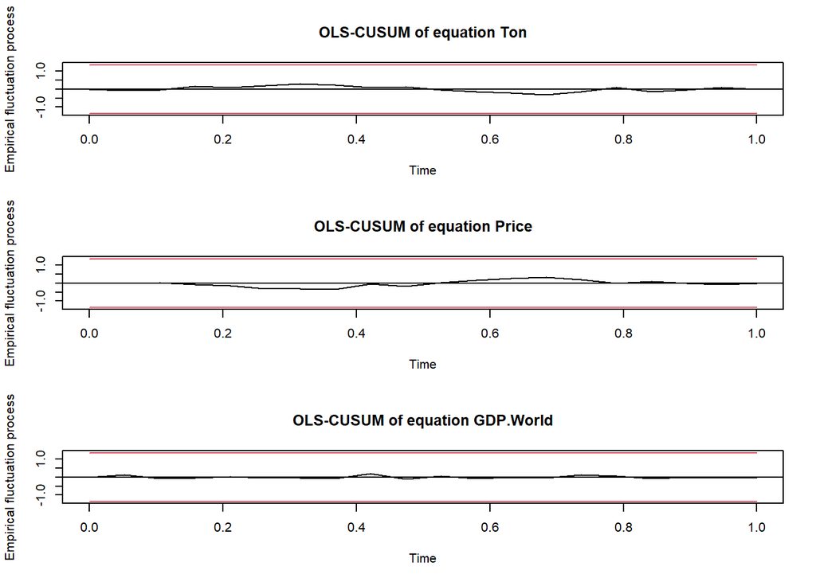

```r
Stability1 <- stability(ModelSoyBeans, type="OLS-CUSUM")
plot(Stability1)
```

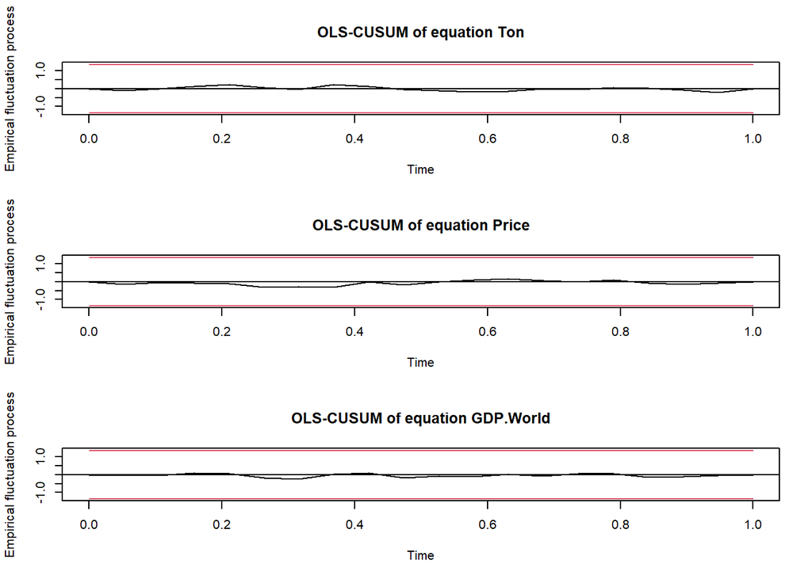

```r
Stability2 <- stability(ModelCorn, type="OLS-CUSUM")
plot(Stability2)
```

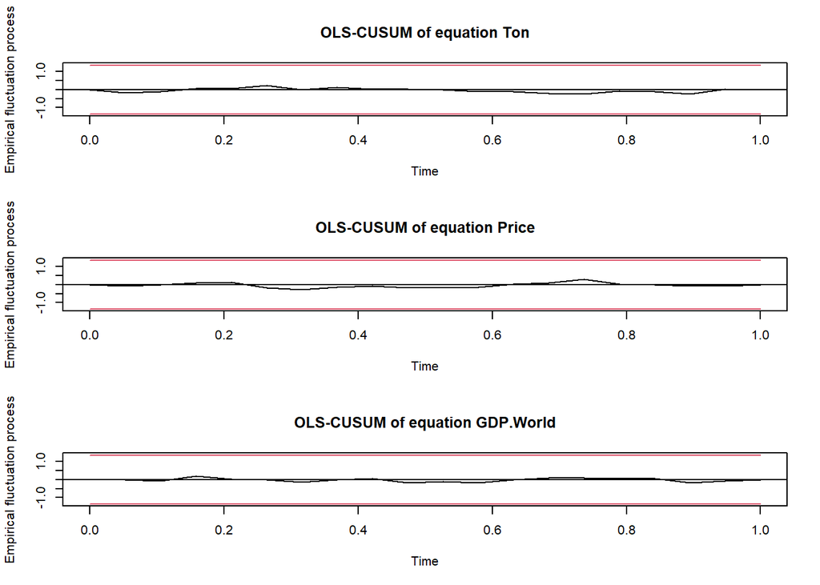

```r
Stability3 <- stability(ModelSoyBeanMeal, type="OLS-CUSUM")
plot(Stability3)
```

- Granger Causality

```r
Grangertonssb <- causality(ModelSoyBeans, cause="Ton")

Grangertonssb <- causality(ModelCorn, cause="Ton")

Grangertonssb <- causality(ModelSoyBeanMeal, cause="Ton")
```

- Variance Decomposition

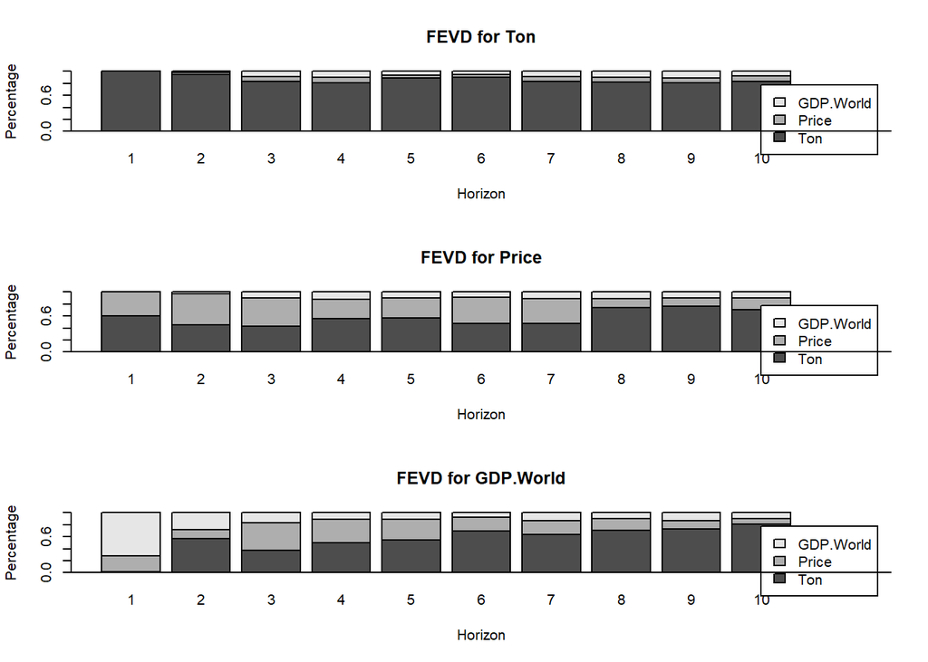

```r
FEVD1 <- fevd(ModelSoyBeans, n.ahead = 10)
plot(FEVD1)
```

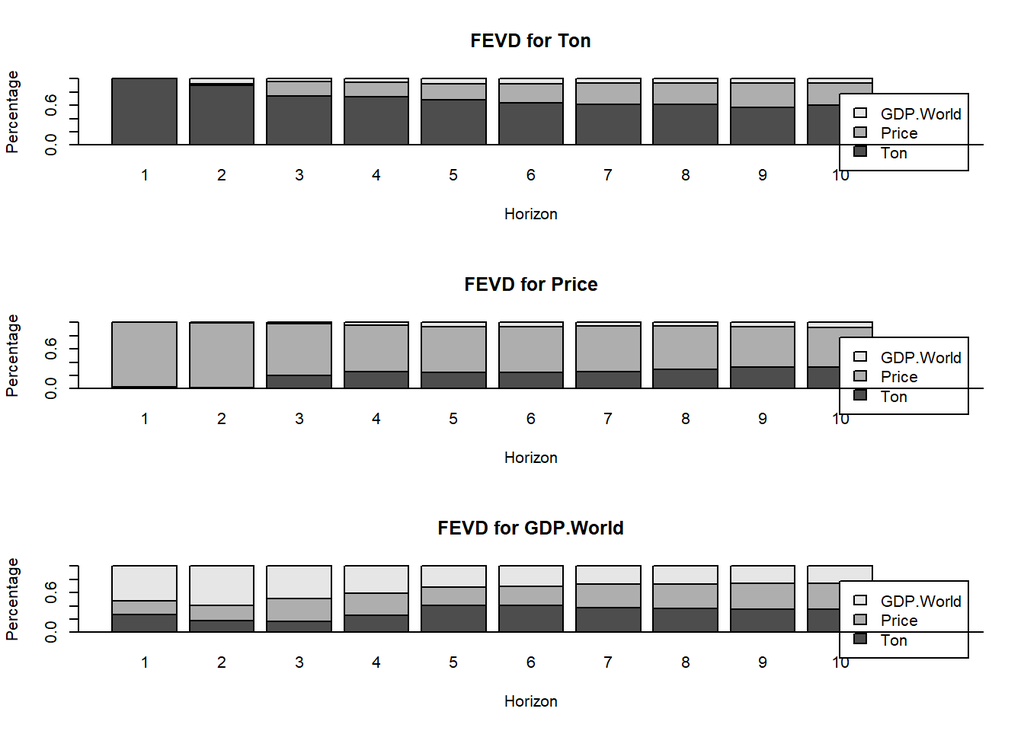

```r
FEVD2 <- fevd(ModelCorn, n.ahead = 10)
plot(FEVD2)
```

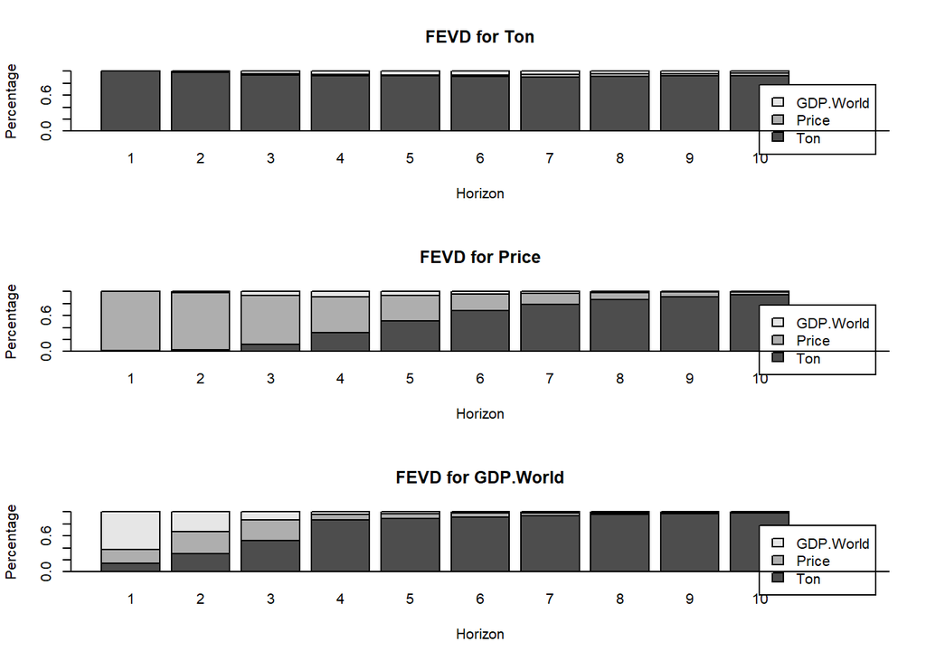

```r
FEVD3 <- fevd(ModelSoyBeanMeal, n.ahead = 10)
plot(FEVD3)
```

### VAR forecasting

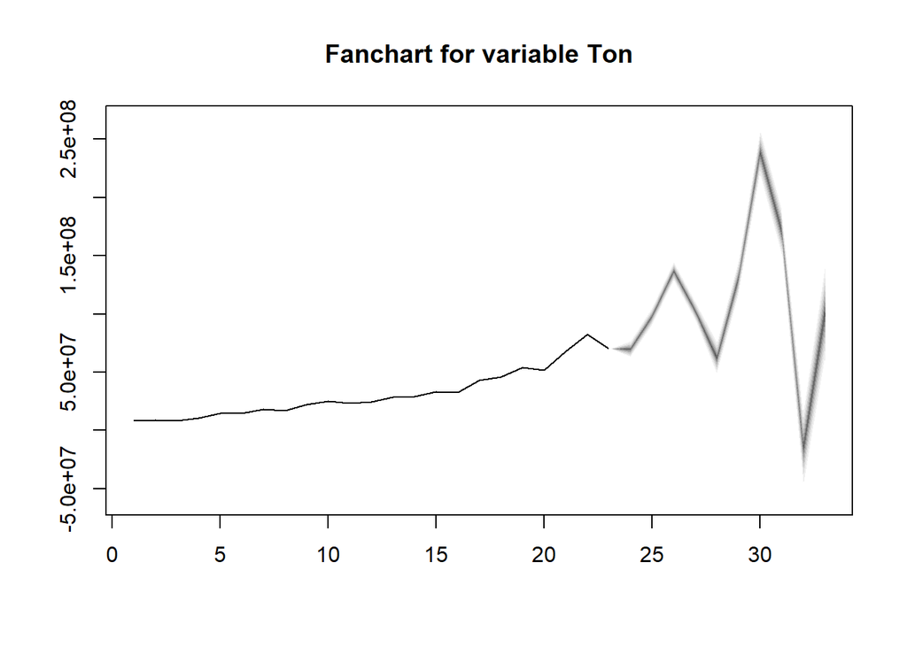

```r
forecast1 <- predict(ModelSoyBeans, n.ahead = 10, ci = 0.95)
fanchart(forecast1, names = "Ton")
```

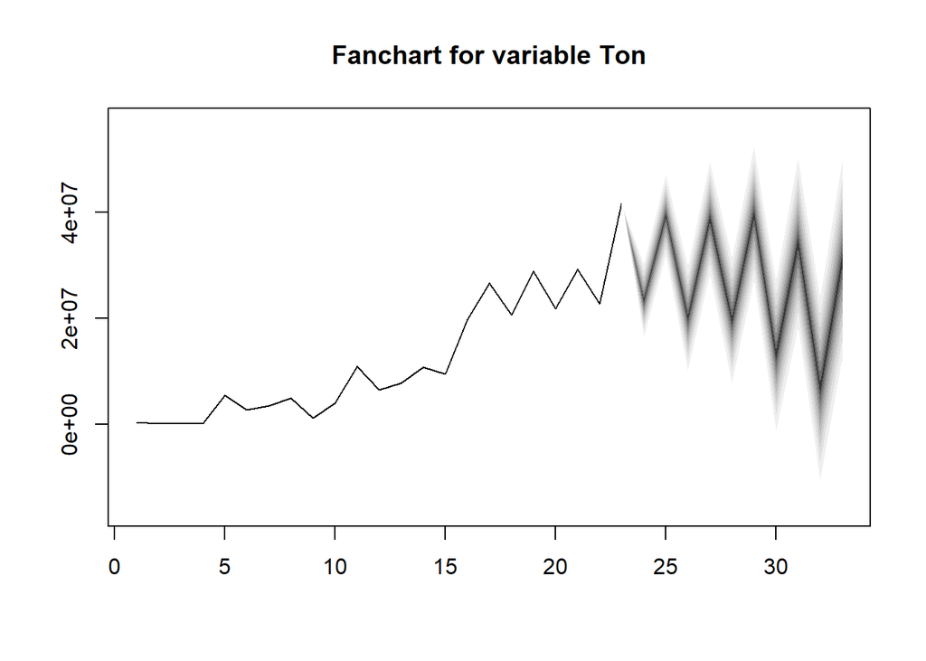

```r
forecast2 <- predict(ModelCorn, n.ahead = 10, ci = 0.95)
fanchart(forecast2, names = "Ton")
```

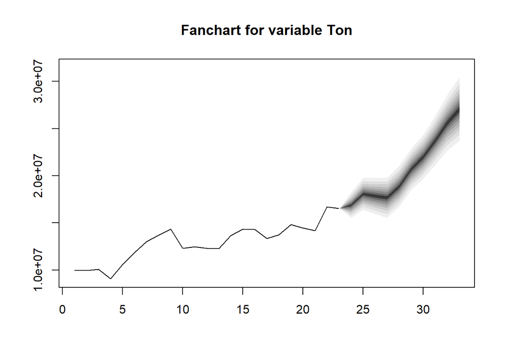

```r
forecast3 <- predict(ModelSoyBeanMeal, n.ahead = 10, ci = 0.95)
fanchart(forecast3, names = "Ton")
```